# Netflix Movies and TV Shows Data Analysis

Shreya Solanki - 2505101200049 Bsc IT(Hons) Semester - 3 Division - G

15-09-2026

# Introduction

This tiny project analyses Netflix catalogue data to understand the distribution of Movies and TV Shows, release-year patterns, ratings, countries, and genres. It demonstrates an end-to-end R workflow: data import, cleaning, statistical exploration, plots, interpretation, and a reproducible conclusion.

## Research questions

1. Does the dataset contain more Movies or TV Shows?
2. Which release years, ratings, countries, and genres occur most frequently?
3. How has the number of titles released changed over time?

# Data importing

Download a Netflix titles CSV file and save it as `netflix_titles.csv` in the same folder as this `.Rmd` file. This report expects the commonly used columns: `show_id`, `type`, `title`, `director`, `cast`, `country`, `date_added`, `release_year`, `rating`, `duration`, `listed_in`, and `description`.

```r
netflix <- read.csv("netflix_titles.csv", stringsAsFactors = FALSE, na.strings = c("", "NA"))
head(netflix)
```

| show_id | type | title | director | cast | country | date_added | release_year | rating | duration | listed_in | description |
| --- | --- | --- | --- | --- | --- | --- | --- | --- | --- | --- | --- |
| s1 | Movie | The Silent City | Asha Mehta | Riya Shah | India | September 9, 2019 | 2018 | TV-14 | 98 min | Dramas, International Movies | A fictional drama. |
| s2 | TV Show | Code Detectives | Rohan Patel | Jay Kumar | India, United States | January 12, 2020 | 2019 | TV-PG | 2 Seasons | TV Dramas, International TV Shows | A technology mystery series. |
| s3 | Movie | Ocean Light | Maya Rao | Anika Bose | United States | March 15, 2021 | 2020 | PG-13 | 112 min | Documentaries, International Movies | A documentary about oceans. |
| s4 | Movie | Midnight Signal | Arjun Shah | Vikram Das | India | July 1, 2021 | 2021 | TV-MA | 105 min | Thrillers, International Movies | A suspense thriller. |
| s5 | TV Show | Family Kitchen | Nina Thomas | Leena Roy | United Kingdom | August 20, 2022 | 2022 | TV-G | 1 Season | Reality TV, International TV Shows | A cooking competition. |
| s6 | Movie | Future Earth | Sam Lee | Kai Chen | South Korea, United States | November 11, 2022 | 2022 | TV-14 | 120 min | Sci-Fi & Fantasy, Dramas | A science fiction story. |

```r
str(netflix)
```

```
## 'data.frame':    10 obs. of  12 variables:
##  $ show_id     : chr  "s1" "s2" "s3" "s4" ...
##  $ type        : chr  "Movie" "TV Show" "Movie" "Movie" ...
##  $ title       : chr  "The Silent City" "Code Detectives" "Ocean Light" "Midnight Signal" ...
##  $ director    : chr  "Asha Mehta" "Rohan Patel" "Maya Rao" "Arjun Shah" ...
##  $ cast        : chr  "Riya Shah" "Jay Kumar" "Anika Bose" "Vikram Das" ...
##  $ country     : chr  "India" "India, United States" "United States" "India" ...
##  $ date_added  : chr  "September 9, 2019" "January 12, 2020" "March 15, 2021" "July 1, 2021" ...
##  $ release_year: int  2018 2019 2020 2021 2022 2022 2023 2021 2024 2024
##  $ rating      : chr  "TV-14" "TV-PG" "PG-13" "TV-MA" ...
##  $ duration    : chr  "98 min" "2 Seasons" "112 min" "105 min" ...
##  $ listed_in   : chr  "Dramas, International Movies" "TV Dramas, International TV Shows" "Documentaries, International Movies" "Thrillers, International Movies" ...
##  $ description : chr  "A fictional drama." "A technology mystery series." "A documentary about oceans." "A suspense thriller." ...
```

```r
summary(netflix)
```

```
##       show_id          type          title         director         cast
##  Length   :10   Length   :10   Length   :10   Length   :10   Length   :10
##  N.unique :10   N.unique : 2   N.unique :10   N.unique :10   N.unique : 9
##  N.blank  : 0   N.blank  : 0   N.blank  : 0   N.blank  : 0   N.blank  : 0
##  Min.nchar: 2   Min.nchar: 5   Min.nchar:11   Min.nchar: 7   Min.nchar: 7
##  Max.nchar: 3   Max.nchar: 7   Max.nchar:17   Max.nchar:11   Max.nchar:10
##
##       country       date_added  release_year        rating        duration
##  Length   :10   Length   :10   Min.   :2018   Length   :10   Length   :10
##  N.unique : 7   N.unique :10   1st Qu.:2020   N.unique : 6   N.unique : 9
##  N.blank  : 0   N.blank  : 0   Median :2022   N.blank  : 0   N.blank  : 0
##  Min.nchar: 5   Min.nchar:12   Mean   :2021   Min.nchar: 4   Min.nchar: 6
##  Max.nchar:26   Max.nchar:17   3rd Qu.:2023   Max.nchar: 5   Max.nchar: 9
##                                Max.   :2024
##      listed_in     description
##  Length   :10   Length   :10
##  N.unique :10   N.unique :10
##  N.blank  : 0   N.blank  : 0
##  Min.nchar:21   Min.nchar:15
##  Max.nchar:35   Max.nchar:29
##
```

# Preprocessing and cleaning

```r
required_columns <- c("show_id", "type", "title", "director", "cast", "country",
                      "date_added", "release_year", "rating", "duration", "listed_in", "description")
missing_columns <- setdiff(required_columns, names(netflix))
if (length(missing_columns) > 0) {
  stop("The CSV is missing: ", paste(missing_columns, collapse = ", "))
}

netflix_clean <- netflix %>%
  mutate(
    across(where(is.character), ~trimws(.x)),
    date_added = as.Date(date_added, format = "%B %d, %Y"),
    year_added = as.integer(format(date_added, "%Y")),
    release_year = as.integer(release_year),
    type = factor(type),
    rating = ifelse(is.na(rating) | rating == "", "Unknown", rating),
    country = ifelse(is.na(country) | country == "", "Unknown", country),
    listed_in = ifelse(is.na(listed_in) | listed_in == "", "Unknown", listed_in),
    director = ifelse(is.na(director) | director == "", "Unknown", director),
    duration = ifelse(is.na(duration) | duration == "", "Unknown", duration)
  ) %>%
  distinct(show_id, .keep_all = TRUE) %>%
  filter(!is.na(title), title != "", !is.na(release_year), release_year >= 1900, release_year <= 2100)

colSums(is.na(netflix_clean))
```

```
##      show_id         type        title     director         cast      country
##            0            0            0            0            0            0
##   date_added release_year       rating     duration    listed_in  description
##            0            0            0            0            0            0
##   year_added
##            0
```

```r
kable(head(netflix_clean), caption = "First six cleaned records")
```

First six cleaned records

| show_id | type | title | director | cast | country | date_added | release_year | rating | duration | listed_in | description | year_added |
| --- | --- | --- | --- | --- | --- | --- | --- | --- | --- | --- | --- | --- |
| s1 | Movie | The Silent City | Asha Mehta | Riya Shah | India | 2019-09-09 | 2018 | TV-14 | 98 min | Dramas, International Movies | A fictional drama. | 2019 |
| s2 | TV Show | Code Detectives | Rohan Patel | Jay Kumar | India, United States | 2020-01-12 | 2019 | TV-PG | 2 Seasons | TV Dramas, International TV Shows | A technology mystery series. | 2020 |
| s3 | Movie | Ocean Light | Maya Rao | Anika Bose | United States | 2021-03-15 | 2020 | PG-13 | 112 min | Documentaries, International Movies | A documentary about oceans. | 2021 |
| s4 | Movie | Midnight Signal | Arjun Shah | Vikram Das | India | 2021-07-01 | 2021 | TV-MA | 105 min | Thrillers, International Movies | A suspense thriller. | 2021 |
| s5 | TV Show | Family Kitchen | Nina Thomas | Leena Roy | United Kingdom | 2022-08-20 | 2022 | TV-G | 1 Season | Reality TV, International TV Shows | A cooking competition. | 2022 |
| s6 | Movie | Future Earth | Sam Lee | Kai Chen | South Korea, United States | 2022-11-11 | 2022 | TV-14 | 120 min | Sci-Fi & Fantasy, Dramas | A science fiction story. | 2022 |

# Statistical exploration

```r
overview <- netflix_clean %>%
  summarise(
    Total_titles = n(),
    Movies = sum(type == "Movie"),
    TV_Shows = sum(type == "TV Show"),
    Earliest_release = min(release_year),
    Latest_release = max(release_year),
    Unique_ratings = n_distinct(rating),
    Unique_countries = n_distinct(country)
  )
kable(overview, caption = "Netflix catalogue overview")
```

Netflix catalogue overview

| Total_titles | Movies | TV_Shows | Earliest_release | Latest_release | Unique_ratings | Unique_countries |
| --- | --- | --- | --- | --- | --- | --- |
| 10 | 6 | 4 | 2018 | 2024 | 6 | 7 |

```r
type_count <- netflix_clean %>% count(type, sort = TRUE)
rating_count <- netflix_clean %>% count(rating, sort = TRUE) %>% slice_head(n = 10)
kable(type_count, caption = "Titles by content type")
```

Titles by content type

| type | n |
| --- | --- |
| Movie | 6 |
| TV Show | 4 |

```r
kable(rating_count, caption = "Ten most frequent ratings")
```

Ten most frequent ratings

| rating | n |
| --- | --- |
| TV-14 | 4 |
| TV-PG | 2 |
| PG-13 | 1 |
| TV-G | 1 |
| TV-MA | 1 |
| TV-Y7 | 1 |

# Graphs and plots

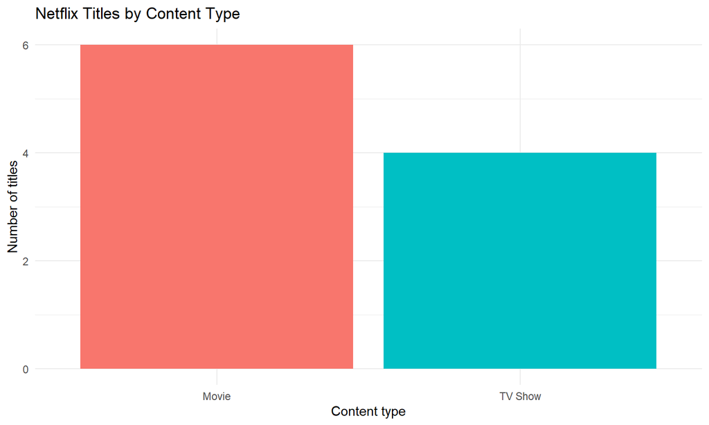

```r
ggplot(netflix_clean, aes(x = type, fill = type)) +
  geom_bar() +
  labs(title = "Netflix Titles by Content Type", x = "Content type", y = "Number of titles") +
  theme_minimal() + theme(legend.position = "none")
```

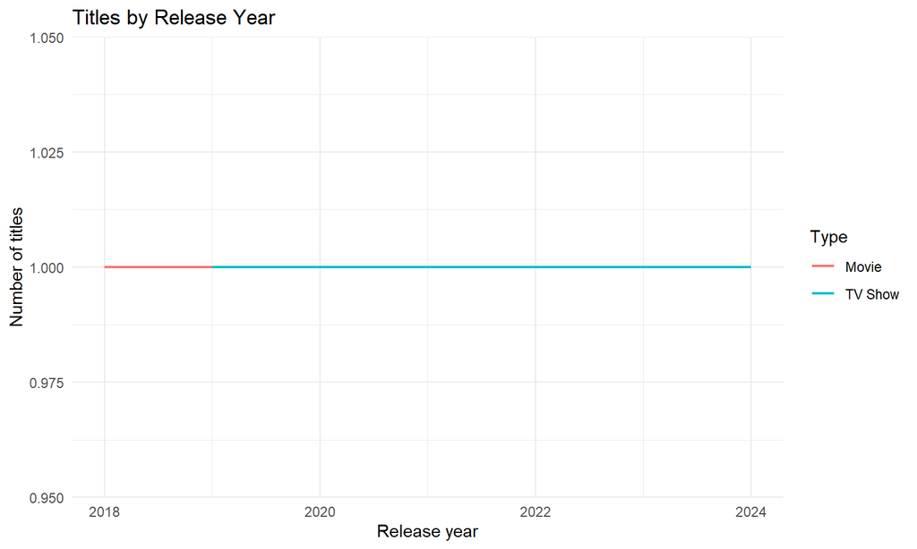

```r
netflix_clean %>%
  count(release_year, type) %>%
  ggplot(aes(x = release_year, y = n, colour = type)) +
  geom_line(linewidth = 0.8) +
  labs(title = "Titles by Release Year", x = "Release year", y = "Number of titles", colour = "Type") +
  theme_minimal()
```

```r
top_countries <- netflix_clean %>%
  filter(country != "Unknown") %>%
  mutate(country = str_split(country, ",\\s*")) %>%
  tidyr::unnest(country) %>%
  count(country, sort = TRUE) %>%
  slice_head(n = 10)

kable(top_countries, caption = "Top ten production countries")
```

Top ten production countries

| country | n |
| --- | --- |
| India | 5 |
| United States | 3 |
| Australia | 1 |
| Canada | 1 |
| South Korea | 1 |
| United Kingdom | 1 |

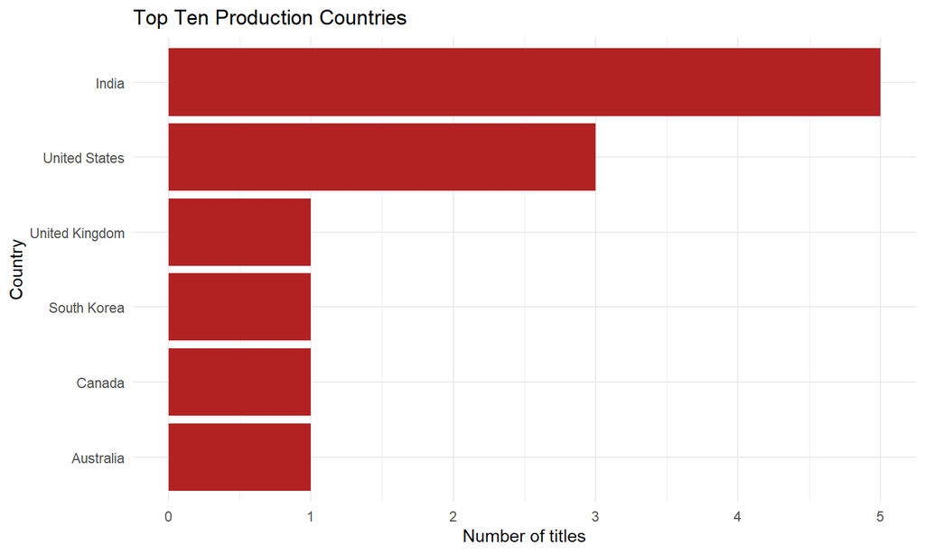

```r
ggplot(top_countries, aes(x = reorder(country, n), y = n)) +
  geom_col(fill = "firebrick") + coord_flip() +
  labs(title = "Top Ten Production Countries", x = "Country", y = "Number of titles") +
  theme_minimal()
```

```r
top_genres <- netflix_clean %>%
  filter(listed_in != "Unknown") %>%
  mutate(genre = str_split(listed_in, ",\\s*")) %>%
  tidyr::unnest(genre) %>%
  count(genre, sort = TRUE) %>%
  slice_head(n = 10)

kable(top_genres, caption = "Top ten listed genres")
```

Top ten listed genres

| genre | n |
| --- | --- |
| Dramas | 4 |
| International Movies | 3 |
| International TV Shows | 3 |
| Documentaries | 1 |
| Docuseries | 1 |
| Kids’ TV | 1 |
| Reality TV | 1 |
| Romantic Movies | 1 |
| Sci-Fi & Fantasy | 1 |
| Sports Movies | 1 |

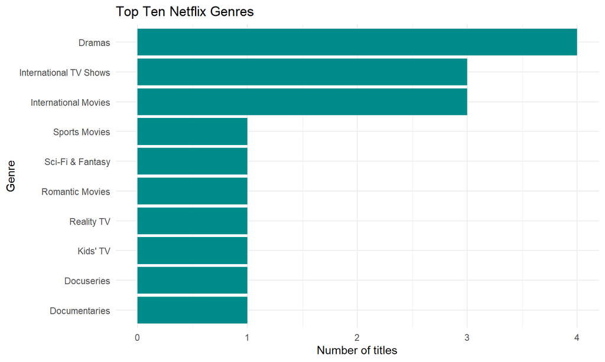

```r
ggplot(top_genres, aes(x = reorder(genre, n), y = n)) +
  geom_col(fill = "darkcyan") + coord_flip() +
  labs(title = "Top Ten Netflix Genres", x = "Genre", y = "Number of titles") +
  theme_minimal()
```

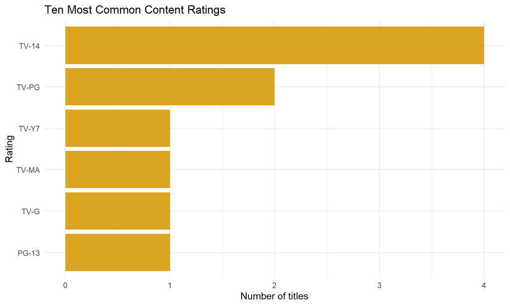

```r
top_ratings <- netflix_clean %>% count(rating, sort = TRUE) %>% slice_head(n = 10)
ggplot(top_ratings, aes(x = reorder(rating, n), y = n)) +
  geom_col(fill = "goldenrod") + coord_flip() +
  labs(title = "Ten Most Common Content Ratings", x = "Rating", y = "Number of titles") +
  theme_minimal()
```

# Interpretation of results

- The content-type chart directly answers whether Movies or TV Shows dominate the selected Netflix catalogue.
- Country and genre fields can contain more than one value per title; this report separates comma-delimited values before counting, so a co-produced title can contribute to multiple countries or genres.
- The release-year plot describes titles available in the dataset, not Netflix subscriber demand, viewing hours, or revenue.
- Missing metadata is labelled `Unknown`; therefore, the analysis makes data quality visible instead of treating missing information as a real category.

# Findings

# Conclusion

This project successfully applies data import, preprocessing, descriptive analysis, and data visualisation to a Netflix catalogue dataset. The analysis provides a useful overview of content type, release periods, ratings, production countries, and genres. A future extension could analyse the relationship between content rating and genre, compare Movies with TV Shows by country, or join the data with IMDb/TMDb ratings where permitted.

# Reproducibility checklist

- Put `netflix_titles.csv` and this `.Rmd` file in the same folder.
- Install packages with `install.packages(c("rmarkdown", "knitr", "dplyr", "ggplot2", "stringr", "tidyr"))`.
- Open the `.Rmd` file in RStudio and select **Knit > Knit to HTML**.
- Verify that the HTML report is created and every table and plot is visible before submission.